# Price per Mile / Revenue Correlation

### Bertrand Dolimier - Coursera Class - February 18th 2018

#### Airline ticket seems to constantly adjust the price of their fare. It is working? It is optimizing their revenue? It is a winning strategy and a necessary reaction to market fluctuation.

#### I am attempting to determine if there is a reasonable correlation between the observed price fluctuation for an airline company and its financial results.

#### Approach:

I collected daily price (agree missed some varation but resources are limited) for each direct flight departing on a specific month for one specific airline. (ie for JFK-LAX departing on Feb. x 2018 we collected price 180, 90, 60, 30, 21, 15, 7, 6, 5, 4, 3, 2, 1, 0 day prior to departure)

### 1 - Normalizing

For all the different flights, we calculated the price per mile as to allow aggregation of multiple routes. We then averaged prices per day prior to departure day. We shall see than price charge per miles varies between $0.15 and $0.70 and variation is extremely dependent on the lag between price observed date and departure date.

### 2 - Box charts price per mile variation per departure lag

[interactive chart not shown]

## 3 - Predicting Quarterly Revenue from price per mile variation

```r
dfa$Revenue <- as.numeric(as.character(dfa$Revenue))
dfa$Quarter_ending <- as.Date(dfa$Quarter_ending, "%m/%d/%y")

fit <- lm(Revenue ~ Day_4+Day_7+Day_15+Day_30+Day_21, data = dfa )
summary(fit)
```

```
##
## Call:
## lm(formula = Revenue ~ Day_4 + Day_7 + Day_15 + Day_30 + Day_21,
##     data = dfa)
##
## Residuals:
##        1        2        3        4        5        6        7        8
##  -7.6096   0.6027   1.2713 -38.6544  25.8094  32.4321  -8.1616  -5.6899
##
## Coefficients:
##             Estimate Std. Error t value Pr(>|t|)
## (Intercept)    802.1      409.0   1.961    0.189
## Day_4         1887.4      850.0   2.221    0.157
## Day_7        -2303.9     3878.9  -0.594    0.613
## Day_15        3931.8     4169.5   0.943    0.445
## Day_30        1028.4     1222.0   0.842    0.489
## Day_21       -2710.1     3311.9  -0.818    0.499
##
## Residual standard error: 41.05 on 2 degrees of freedom
## Multiple R-squared:  0.9136, Adjusted R-squared:  0.6977
## F-statistic: 4.231 on 5 and 2 DF,  p-value: 0.2022
```

```r
coef(fit)
```

```
## (Intercept)       Day_4       Day_7      Day_15      Day_30      Day_21
##     802.076    1887.418   -2303.878    3931.789    1028.374   -2710.069
```

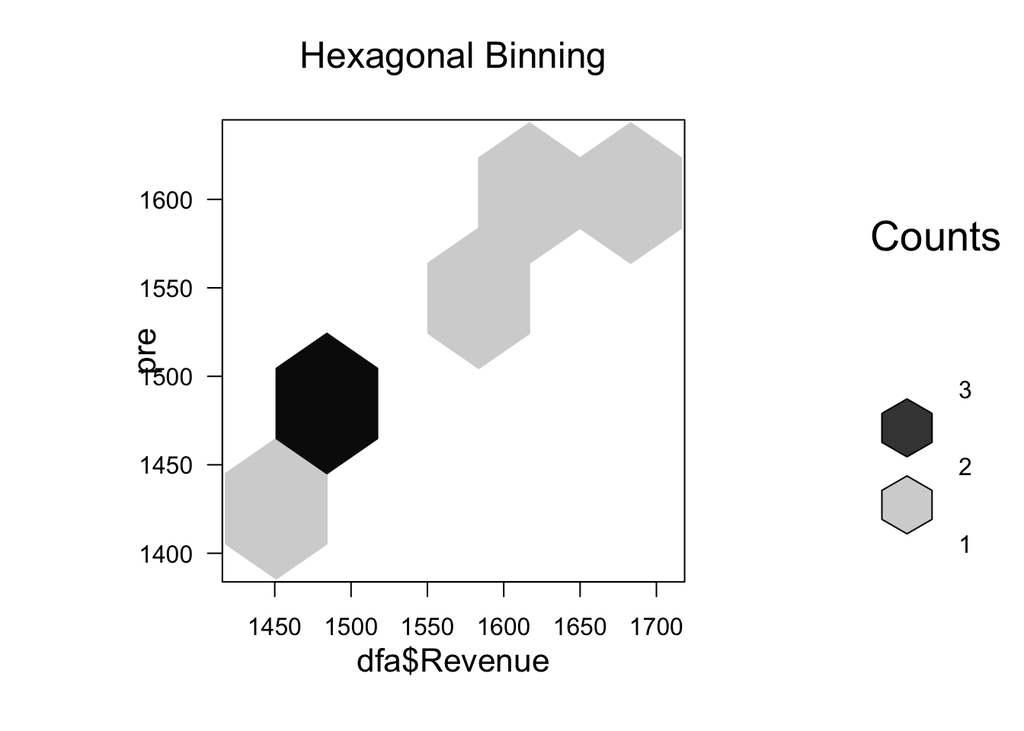

```r
pre <- predict( fit, dfa)
dfa$pre <- pre

bin<-hexbin(dfa$Revenue, pre, xbins=3)
plot(bin, main="Hexagonal Binning")
```

```r
plot_ly(data = dfa, x = dfa$Revenue, y = dfa$pre)
```

[interactive chart not shown]

#### Conclusion:

> No matter which plot_ly graph we select, the high correlation is easily observable…

### 4 - Visual confirmation chart

Chart below is representing normalized (around their means) the fields: revenue, prediction and day 0 to 180

[interactive chart not shown]

#### Conclusion:

Again easy to see how revenue and prediction lines are correlated.